# Principios de Estadística Aplicada con R

Introducción al curso

Gabriel Carrasco Escobar

Universidad Peruana Cayetano Heredia

Jorge Ruiz Cabrejos

Universidad Peruana Cayetano Heredia

08 de febrero del 2018

Rutinas y comandos complementarios del curso *Principios de Estadística Aplicada con R (PEAR)*

*Cualquier problema con este código, porfavor contactar a gabriel.carrasco@upch.pe*

# Contenido

# Pre-requisitos

Para el curso deberá tener instalados los programas

- R
- RStudio

Además, R deberá tener instalados los paquetes que se encuentran dentro del archivo “pkg_install_v1.6.R” el cúal se les hará llegar a inicios del curso:

- Devtools
- Rafalib
- Downloader
- Epidisplay
- Doby
- Dplyr
- Ggplot2
- Sfsmisc
- Moments
- Readr
- Readxl
- Haven
- Rmardown
- Gdata
- Exact2x2
- Clinfun
- Rvaidememoire

Le recomendamos crear una carpeta donde coloque los archivos que utilizaremos a lo largo del curso. (Ej. “Estadística con R 2018 - l”)

A continuación encontrara un paso a paso para:

1. Descargar e Instalar R
2. Descargar e instalar RStudio
3. Descargar e instalar los paquetes que se utilizaran durante el curso

Requiere de una laptop donde instalar los programas y de una conexión a internet estable durante el proceso de descarga e instalación.

### Descargar e instalar R

##### 1. Ingrese a: https://cran.r-project.org/

Una vez dentro, seleccione la opción que corresponda a su sistema operativo (Linux, macOS (Apple), Windows.

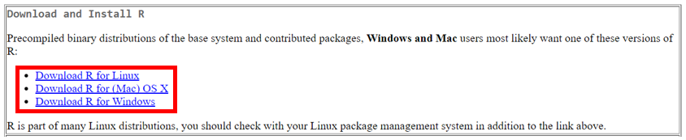

Para esta guía, utilizaremos la versión de Windows (Download R for Windows).

*Nota: Si su sistema operativo es Linux o macOS (Apple) podrá encontrar instrucciones detalladas al ingresar a la opción que le corresponda.*

##### 2. Al ingresar, seleccione la opción base y luego seleccione Download R for Windows.

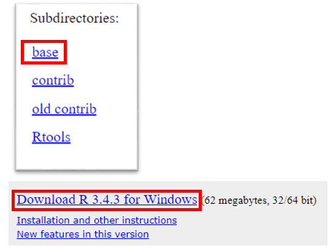

Se descargará el archivo de instalación de R.

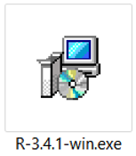

##### 3. Ingrese al archivo de instalación (doble click). Siga las instrucciones que aparecerán en pantalla (Asistente de instalación de R for Windows).

### Descargar e instalar RStudio

##### 1.Ingrese a: https://www.rstudio.com/products/rstudio/download/

Una vez dentro, diríjase al final de la página y seleccione la opción que corresponda a su sistema operativo (Linux, macOS (Apple), Windows)

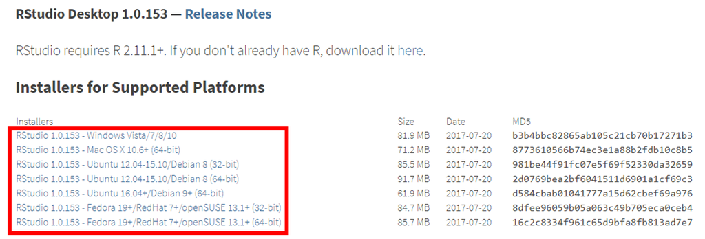

[figure not shown]

### Descargar e instalar los paquetes para el curso de Estadística

Como requisito para esta parte, deberá tener instalado los programas R y RStudio en su computadora.

##### 1. Descargue el archivo pkg_install_v1.6.R (el cúal se entrega al inicio del curso)

##### 2. Ingrese al programa RStudio

Una vez dentro, diríjase File a la barra de tareas y seleccione la opción Open File.

[figure not shown]

Aparecerá una ventana emergente

[figure not shown]

Tras abrir el archivo se obtendrá una ventana como la siguiente:

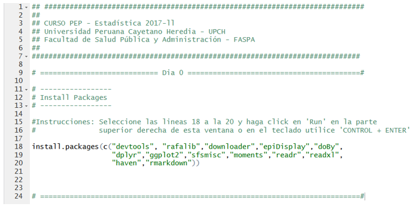

##### 4. Las líneas 18 a la 20 contienen el comando de instalación para los paquetes que utilizaremos en el curso.

Seleccione las lineas 18 a la 20 y haga click en Run en la parte superior derecha de esta ventana o en el teclado utilice Ctrl + Enter.

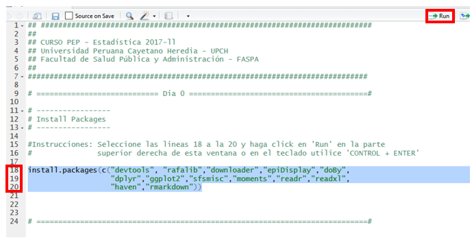

La instalación demora menos de 5 minutos. Es normal que aparezcan algunas ventanas de descarga mientras se instalan los paquetes.

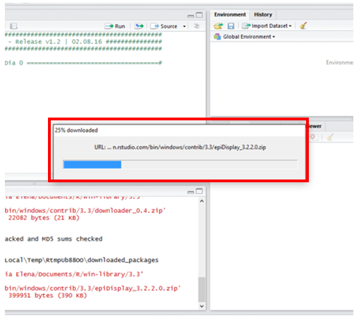

##### 5. Concluida la instalación, aparecerá en la ventana inferior izquierda de RStudio la siguiente línea de la consola con el símbolo “>”.

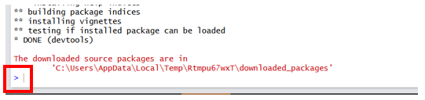

Si deseas comprobar que los paquetes se han instalado correctamente, puedes encontrar los paquetes instalados en la parte inferior derecha de RStudio, pestaña “Packages”.

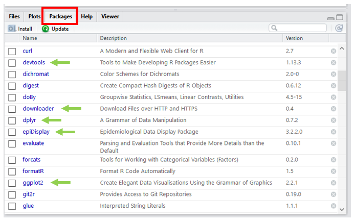

# Recursos adicionales

#### 1. Tabla de operadores aritméticos

| Operador | Descripción |
| --- | --- |
| + | Adición |
| - | Substracción |
| * | Multiplicación |
| / | División |
| ^ o ** | Potenciación |

# Changelog

[25-01-2018] Día 2 añadido.

[15-01-2018] Día 1 añadido.

[01-01-2018] Primera versión.